# Práctica 4: Estimación Puntual e Intervalos de Confianza

# 1. Estimación Puntual

## Ejercicio 1.1.

Considera el Problema 2 del Tema 5. Representa gráficamente la eficiencia de $\hat{\mu}_1$ con respecto a $\hat{\mu}_2$ para una secuencia de valores de $\mu=1,2,\ldots,50$.

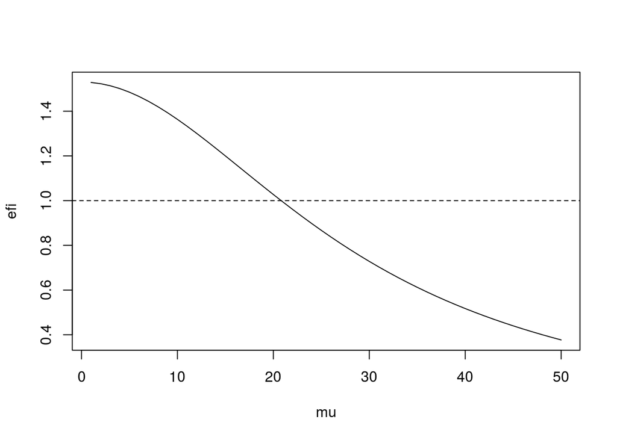

```r
  mu<-1:50
  efi<-0.125/(0.081675+0.0001*mu^2)

  plot(mu,efi,type="l")
  abline(h=1,lty=2)
```

## Ejercicio 1.2.

Sea $X \sim Bin(n,\pi)$. Calcula la eficiencia relativa de T2 respecto a T1 para valores de $\pi$ en el intervalo (0, 1) y n tomando valores de 1 a 10.

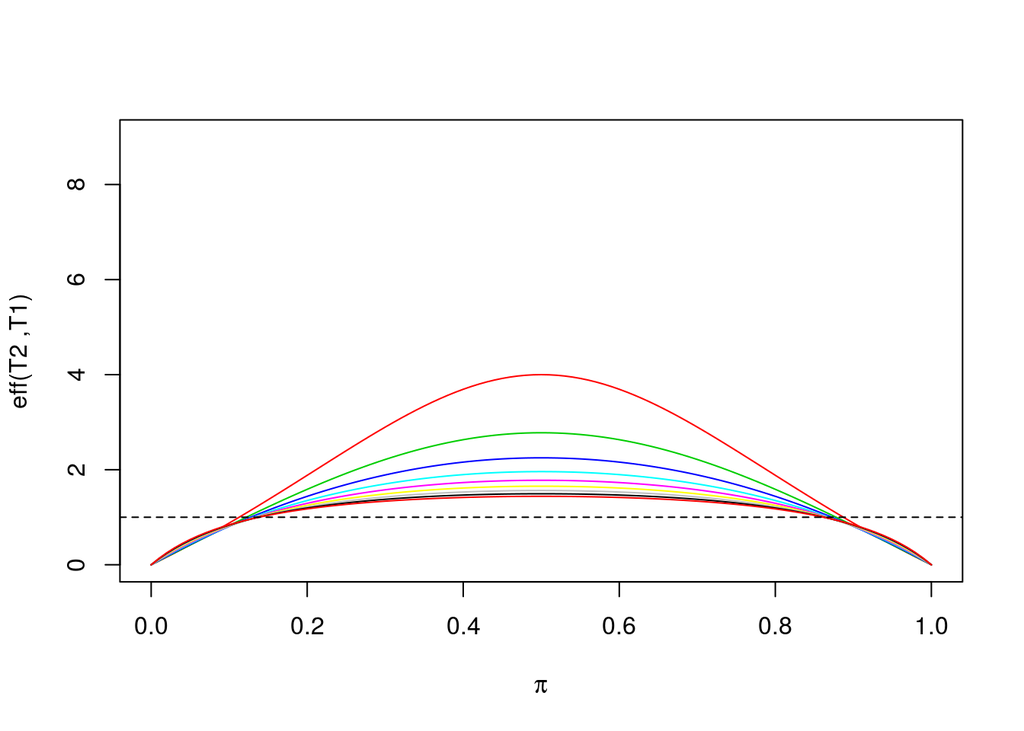

```r
rel.ef<-function(p,n){
  (p*(1-p)/n)/((n*p*(1-p)+(1-2*p)^2)/(n+2)^2)
}

p <- seq(0,1,0.01)
plot(p, rel.ef(p,1), type="n", xlab=expression(pi),ylab="eff(T2 ,T1)", col=1, ylim=c(0,9))
for(n in 2:10){
 lines(p,rel.ef(p,n),col=n)
}
abline(h=1,lty=2)
```

Si queremos incluir información extra en el gráfico podemos poner títulos, leyendas, etc. Por ejemplo:

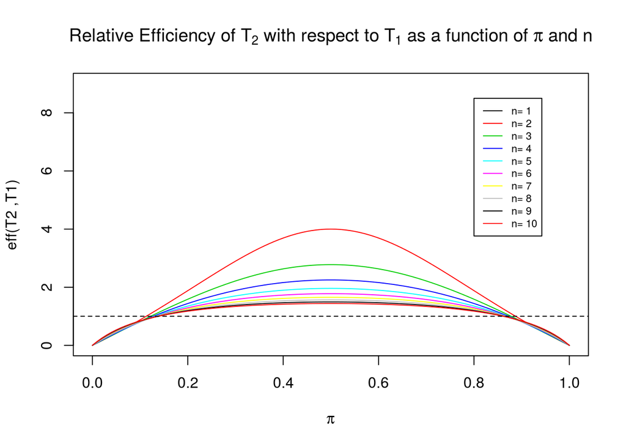

```r
rel.ef<-function(p,n){
  (p*(1-p)/n)/((n*p*(1-p)+(1-2*p)^2)/(n+2)^2)
}

p <- seq(0,1,0.01)
plot(p, rel.ef(p,1), type="n", xlab=expression(pi),ylab="eff(T2 ,T1)", col=1, ylim=c(0,9))
for(n in 2:10){
 lines(p,rel.ef(p,n),col=n)
}
abline(h=1,lty=2)
 names <- array(0, 10)
 for(i in 1:10){names[i] <- paste("n=",i)}
 legend(0.8, 8.5, legend=names, lty=1, col=c(1:10), cex=0.7)
 title(expression(paste(plain("Relative Efficiency of "),T[2],
                       plain(" with respect to "), T[1] ,plain(" as a function of ")*pi,
                       plain(" and " )*n)))
```

# 2. Intervalos de Confianza. Parte I

## Ejercicio 2.1.

Genera 100 muestras de tamaño $n=10$ de una $N(\mu=87,\sigma=7)$. Para cada muestra, calcula un intervalo de confianza al 95% para la media poblacional. Representa gráficamente los intervalos de confianza, resaltando aquellos que no contengan $\mu=87$. ¿Cuántos intervalos no contienen el verdadero valor de la media poblacional $\mu=87$? Establece el valor de la semilla aleatoria en 65 y usa la función `cisim` del paquete `PASWR2` para generar las muestras y representar gráficamente los intervalos.

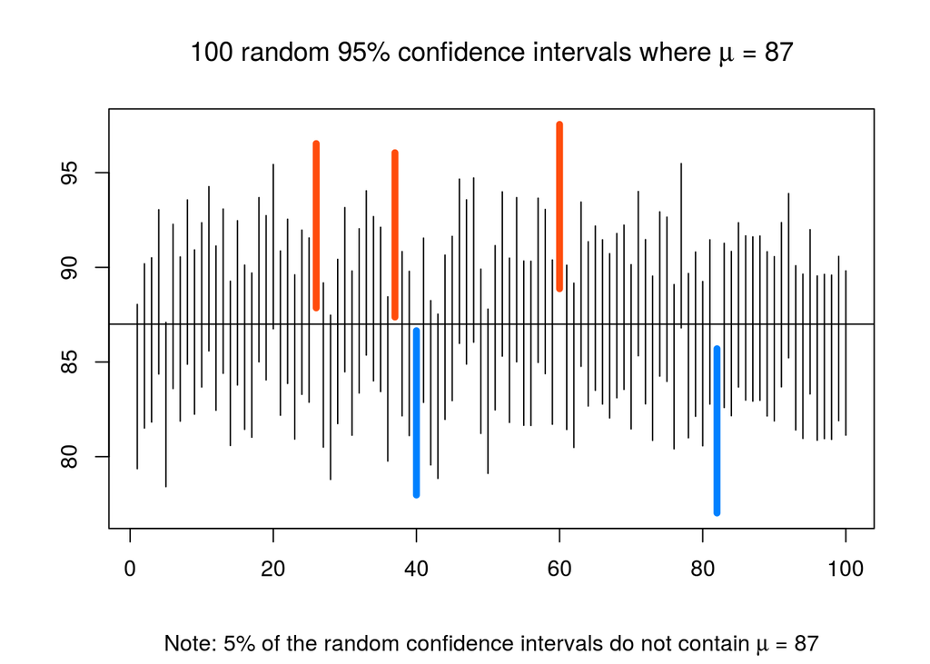

```
## 5 % of the random confidence intervals do not contain Mu = 87 .
```

```r
  library(PASWR2)
  set.seed(65)
  cisim(samples=100,n=10, parameter = 87, sigma = 7, conf.level = 0.95)
```

## Ejercicio 2.2.

Repite el ejercicio con muestras de tamaño $n=50$ y $n=10000$. ¿Cuántos intervalos no contienen el verdadero valor de la media poblacional $\mu=87$? ¿Depende el nivel de confianza del tamaño de la muestra $n$? ¿Cómo afecta el tamaño de la muestra a los intervalos de confianza? Establece el valor de la semilla aleatoria en 65.

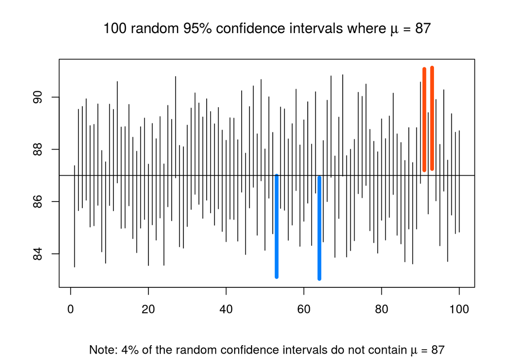

```
## 4 % of the random confidence intervals do not contain Mu = 87 .
```

```r
  set.seed(65)
  cisim(samples=100,n=50, parameter = 87, sigma = 7, conf.level = 0.95)
```

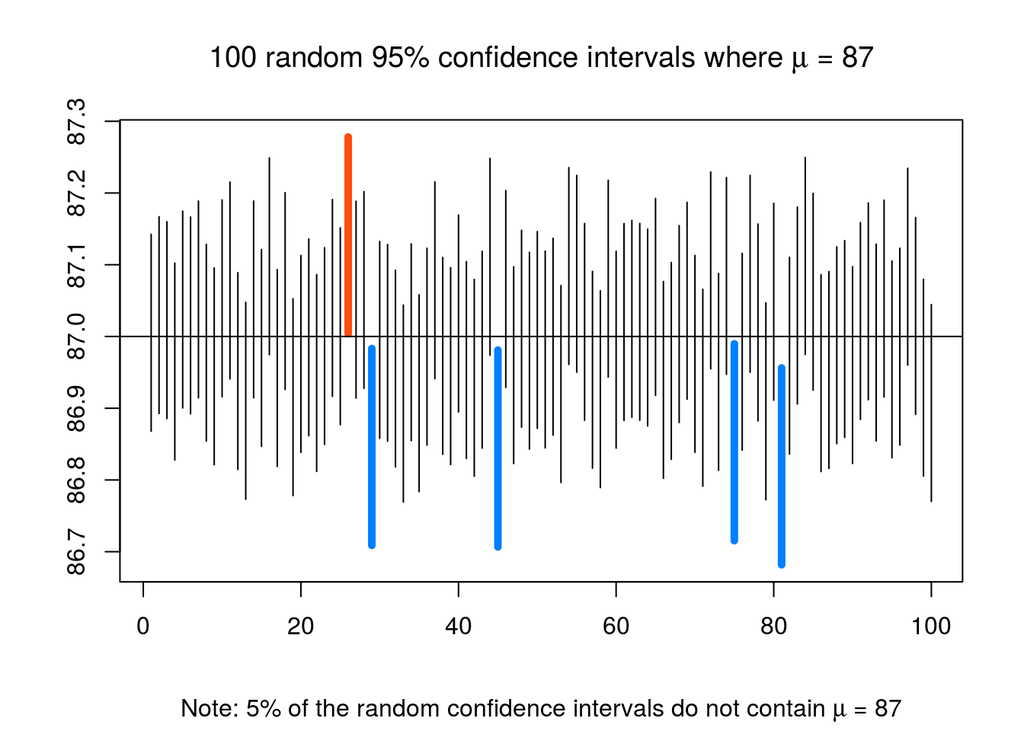

```
## 5 % of the random confidence intervals do not contain Mu = 87 .
```

```r
  set.seed(65)
  cisim(samples=100,n=10000, parameter = 87, sigma = 7, conf.level = 0.95)
```

## Ejercicio 2.3.

Usa el data.frame `GROCERY` del paquete `PASWR2` para calcular un intervalo de confianza al 97% para la verdadera media del gasto semanal en frutas y verduras de los hogares del condado de Watauga (Carolina del Norte). Verifica que el gasto semanal sigue una distribución normal y asume que la varianza poblacional es $\sigma^2=900$ dólares$^2$.

X: gasto semanal en frutas y verduras de los hogares del condado de Watauga en dolares

Para poder hacer la estimación por intervalos de confianza, X debe seguir una distribución normal. Dado que no nos dicen nada sobre la normalidad de $X$ deberemos comprobarlo. Para ello podemos usar las gráficas cuantil-cuantil (QQ-plot) que podemos obtener de la siguiente manera

```r
library(PASWR2)
str(GROCERY) # vemos la estructura del objeto GROCERY.
```

```
## 'data.frame':    30 obs. of  1 variable:
##  $ amount: num  90.7 104 85.6 134.7 108.8 ...
```

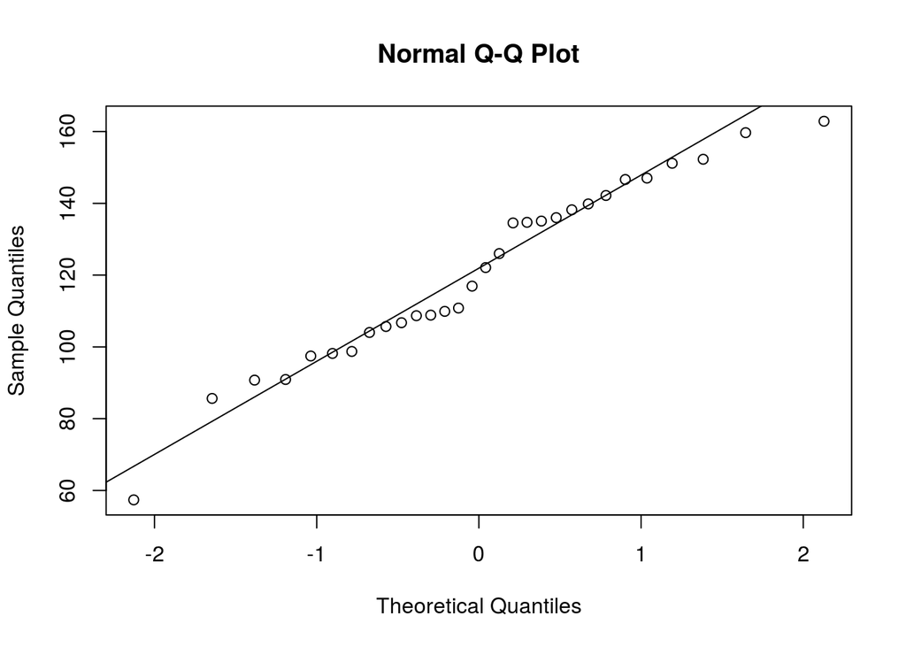

```r
# es un data.frame y los datos que vamos a usar están en GROCERY$amount
# Obtenemos el QQ-plot con los siguientes comandos
qqnorm(GROCERY$amount)
qqline(GROCERY$amount)
```

En la gráfica QQ-plot observamos un conjunto de puntos y una línea. Los puntos representan los cuantiles de la muestra (eje Y) respecto a los cuantiles teóricos de una normal (eje X). Por otra parte la línea marca donde quedarían los cuantiles de una normal teórica. Mediante esta herramienta gráfica, podemos comparar nuestra muestra con una distribución normal teórica. Los puntos de la gráfica, incluso si los datos provienen de una población normal, difícilmente van a ajustarse de forma perfecta a la línea ya que los datos corresponden a una muestra aleatoria. No obstante, podremos asumir que los datos provienen de una distribución normal si los puntos, o la gran mayoría de ellos, están dispuestos más o menos a lo largo de la línea. Por tanto, y viendo la gráfica obtenida, en este caso podremos asumir que la muestra proviene de una población normal.

Las condiciones que tenemos en este caso son:

- Asumimos que la población normal (ver justificación arriba)
- Varianza conocida

Por lo que bajo estas condiciones podemos pasar a calcular el intervalo de confianza usando el siguiente comando de `R`

```r
z.test(GROCERY$amount,sigma.x=30,conf.level = 0.97)$conf
```

```
## [1] 108.7473 132.5194
## attr(,"conf.level")
## [1] 0.97
```

Por tanto: CI$_{97\%}(\mu_X)$= [108.7473, 132.5194] $

Finalmente debemos hacer la INTERPRETACIÓN: Tenemos una confianza del 97% en que el verdadero valor del gasto medio semanal en frutas y verduras de los hogares del condado de Watauga está entre 108.7473 y 132.5194 $.

## Ejercicio 2.4.

Determina el tamaño de muestra necesario para estimar el verdadero valor de $\mu$ con un error de $±0.02$ y un nivel de confianza del $95\%$ cuando muestreamos de una distribución normal con $\sigma=0.1$.

```r
  nsize(b=0.02,sigma=0.1,conf.level=0.95,type="mu")
```

```
##
## The required sample size (n) to estimate the population
## mean with a 0.95 confidence interval so that the margin
## of error is no more than 0.02 is 97 .
```

```r
  ## o usando la fórmula

 n<-(qnorm(0.975)*0.1)^2/(0.02)^2
 n
```

```
## [1] 96.03647
```

```r
 # y redondeamos hacia arriba el valor obtenido
 ceiling(n)
```

```
## [1] 97
```

## Ejercicio 2.5

Usa el data.frame `HOUSE` del paquete `PASWR2` para calcular un intervalo de confianza al 95% para el precio medio de las casas con tres dormitorios y dos cuartos de baño en el condado de Watauga (Carolina del Norte). Verifica que el precio es un variable aleatoria normal. Los precios están en miles de dólares.

X: precio de las casas con tres dormitorios y dos cuartos de baño en el condado de Watauga (Carolina del Norte) en miles de dólares.

Obtenemos la gráfica QQ-plot:

```r
str(HOUSE)
```

```
## 'data.frame':    14 obs. of  2 variables:
##  $ neighborhood: Factor w/ 6 levels "Blowing Rock",..: 6 6 6 1 5 1 2 1 6 1 ...
##  $ price       : num  185 160 298 270 190 ...
```

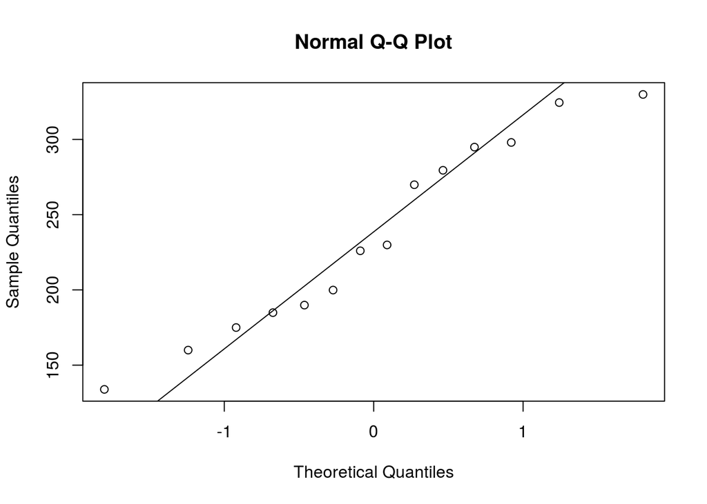

```r
qqnorm(HOUSE$price)
qqline(HOUSE$price)
```

Condiciones:

- Asumimos que la población es normal, porque en la gráfica QQ-plot podemos ver que los puntos que corresponden a los cuantiles de la muestra se ajustan bastante bien a la línea que representa los cuantiles teóricos de una normal (ver la gráfica anterior)
- La varianza es desconocida

Por tanto, bajo esas condiciones podemos usar el siguiente comando para obtener el intervalo de confianza:

```r
t.test(HOUSE$price, conf.level = 0.95)$conf
```

```
## [1] 198.5424 272.3433
## attr(,"conf.level")
## [1] 0.95
```

Por tanto: CI$_{95\%}(\mu_X)$= [198.5424, 272.3433] miles de $

INTERPRETACIÓN: Tenemos una confianza del 95% en que el verdadero valor del precio medio de las casas con tres dormitorios y dos cuartos de baño en el condado de Watauga (Carolina del Norte) está entre 198.5424 y 272.3433 miles de $.

# 3. Intervalos de Confianza. Parte II

## Ejercicio 3.1

Usa el data.frame `APPLE` del paquete `PASWR2` para calcular un intervalo de confianza al 95% para la diferencia entre el grado medio de la dureza de las manzanas recién cogidas del árbol (`fresh`) y las almacenadas durante una semana (`warehouse`). Comprueba que se pueda asumir que la variable aleatoria `hardness` (grado de dureza en kg/cm$^2$) sigue una distribución normal para ambos tipos de manzanas. Asume que la varianza de `hardness` es conocida e igual para los dos tipos de manzanas $\sigma^2=2.25 \ \ (kg/cm^2)^2$.

X: grado de dureza de las manzanas recién cogidas del árbol en kg/cm$^2$

Y: grado de dureza de las manzanas almacenadas durante una semana en kg/cm$^2$

Realizamos las gráficas QQ-plot para comprobar la normalidad

```r
  library(PASWR2)
  APPLE
```

| hardness | location |
| --- | --- |
| 7.79 | warehouse |
| 7.11 | warehouse |
| 6.27 | warehouse |
| 7.22 | warehouse |
| 8.83 | warehouse |
| 10.50 | warehouse |
| 9.17 | warehouse |
| 6.31 | warehouse |
| 8.39 | warehouse |
| 6.19 | warehouse |

[output cut: 24 more lines]

```r
  freshH <- APPLE$hardness[APPLE$location =="fresh"]
  freshH
```

```
##  [1] 7.27 6.65 5.76 6.53 8.09 9.56 8.38 5.83 7.70 5.86 5.53 6.54 9.20 7.89 7.77
## [16] 6.48 8.28
```

```r
  wareH <- APPLE$hardness[APPLE$location =="warehouse"]
  wareH
```

```
##  [1]  7.79  7.11  6.27  7.22  8.83 10.50  9.17  6.31  8.39  6.19  6.31  7.17
## [13] 10.05  8.58  8.42  7.07  8.83
```

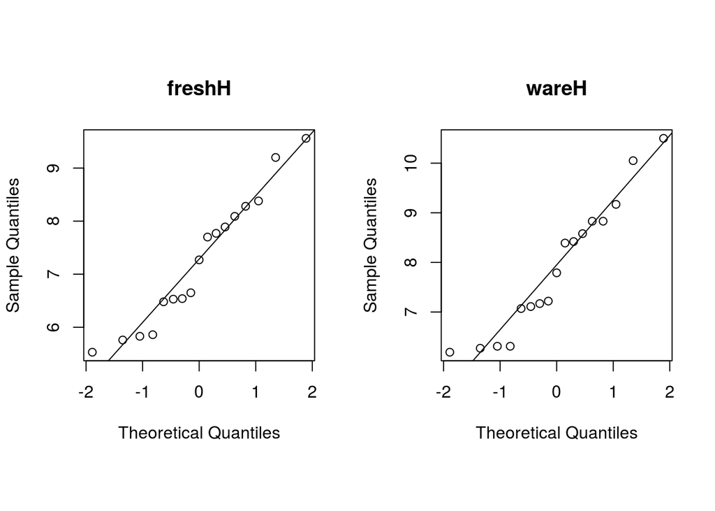

```r
  par(mfrow=c(1,2),pty="s")
  qqnorm(freshH,main="freshH")
  qqline(freshH)
  qqnorm(wareH,main="wareH")
  qqline(wareH)
```

Otra opción para comprobar la normalidad de los datos es usar la función *exploratory data analysis* (`eda()`) del paquete `PASWR2`. Que entre otras cosas nos devuelve la gráfica QQ-plot que ya sabemos interpretar. Otras gráficas que muestra son el `boxplot` de la muestra además del histograma y el gráfico de densidad. En el caso de la normal teórica, la gráfica boxplot será totalmente simétrica y el gráfico de densidad correspondería con la función de densidad de la normal (simétrica con respecto a la media y con forma acampanada). Por tanto, para poder asumir normalidad, los gráficos obtenidos deberían parecerse a los gráficos que obtendríamos con una normal teórica. Aunque siempre encontraremos diferencias debido a que los datos corresponden a una muestra aleatoria.

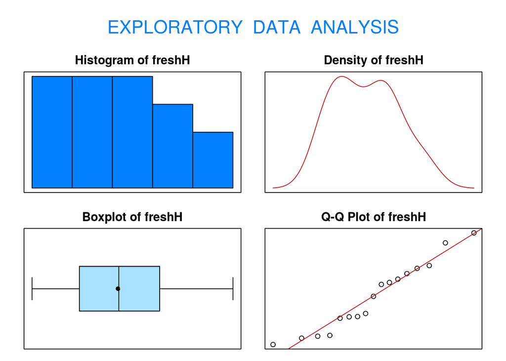

```
## Size (n)  Missing  Minimum   1st Qu     Mean   Median   TrMean   3rd Qu
##   17.000    0.000    5.530    6.480    7.254    7.270    7.254    8.090
##      Max    Stdev      Var  SE Mean   I.Q.R.    Range Kurtosis Skewness
##    9.560    1.229    1.510    0.298    1.610    4.030   -1.225    0.245
## SW p-val
##    0.388
```

```r
  eda(freshH)
```

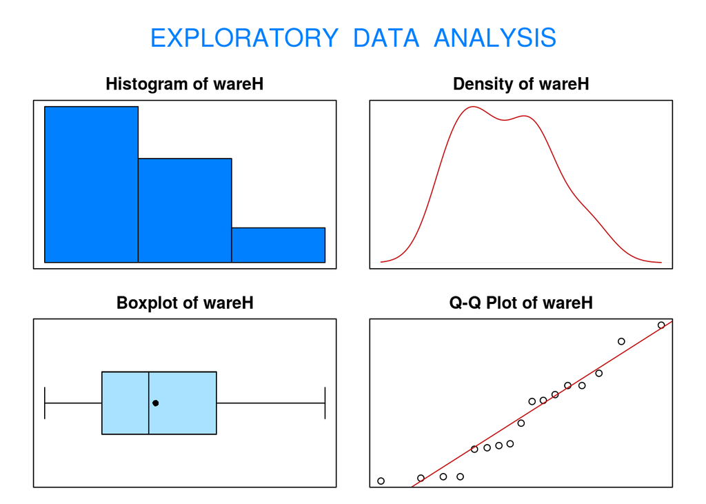

```
## Size (n)  Missing  Minimum   1st Qu     Mean   Median   TrMean   3rd Qu
##   17.000    0.000    6.190    7.070    7.895    7.790    7.895    8.830
##      Max    Stdev      Var  SE Mean   I.Q.R.    Range Kurtosis Skewness
##   10.500    1.338    1.791    0.325    1.760    4.310   -1.138    0.321
## SW p-val
##    0.241
```

```r
  eda( wareH)
```

En este caso tenemos las siguientes condiciones:

- 2 poblaciones independientes ya que las manzanas son cogidas de forma aleatoria del árbol o del almacén.
- Asumimos que las dos poblaciones son normales ya que para ambas muestras los puntos que representan los cuantiles de la muestra se ajustan bastante bien a la línea que representa los cuantiles de una normal teórica.
- Las varianzas son conocidas e iguales.

Por tanto, obtendríamos el intervalo de confianza de la siguiente manera:

```r
 z.test(x=freshH,y=wareH,sigma.x=1.5,sigma.y=1.5,conf.level = 0.95)$conf
```

```
## [1] -1.6489814  0.3678049
## attr(,"conf.level")
## [1] 0.95
```

Por tanto: CI$_{95\%}(\mu_X - \mu_Y)$= [-1.649, 0.3678] kg/cm$^2$

INTERPRETACIÓN: Tenemos una confianza del 95% en que el verdadero valor de la diferencia entre la dureza media de las manzanas recién cogidas del árbol y la dureza media de las manzanas almacenadas durante una semana está entre -1.649 y 0.3678 kg/cm$^2$.

## Ejercicio 3.2

El data.frame `CALCULUS` del paquete `PASWR2` contiene datos con las notas en la asignatura de Matemáticas de estudiantes que han completado un curso de cálculo ($X$) y aquellos que no lo completaron ($Y$). Verifica que se pueda asumir normalidad y calcula:

1. Intervalo de confianza al 95% para el cociente de varianzas de los estudiantes que han completado y los que no han completado el curso de cálculo. ¿Se puede asumir que las varianzas son iguales?
2. Intervalo de confianza al 95% para la diferencia en las notas medias de los estudiantes que han completado y los que no han completado el curso de cálculo.

X: nota en Matemáticas de los estudiantes que han completado Cálculo

Y: nota en Matemáticas de los estudiantes que no han completado Cálculo.

Obtenemos los gráficos QQ-plot:

```r
 CALCULUS
```

| score | calculus |
| --- | --- |
| 82 | Yes |
| 90 | Yes |
| 85 | Yes |
| 87 | Yes |
| 86 | Yes |
| 79 | Yes |
| 85 | Yes |
| 92 | Yes |
| 89 | Yes |
| 82 | Yes |

[output cut: 26 more lines]

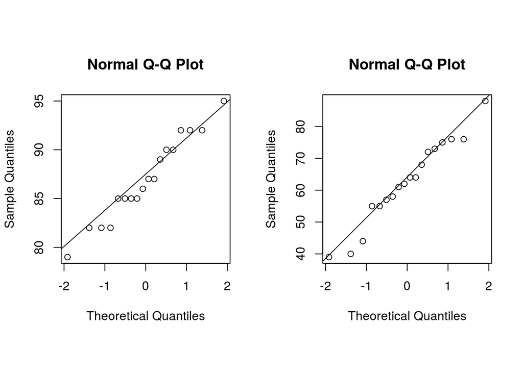

```r
 ScoreYesCalc<-CALCULUS$score[CALCULUS$calculus =="Yes"]
 ScoreNoCalc<-CALCULUS$score[CALCULUS$calculus =="No"]

 par(mfrow=c(1,2),pty="s")
 qqnorm(ScoreYesCalc)
 qqline(ScoreYesCalc)
 qqnorm(ScoreNoCalc)
 qqline( ScoreNoCalc)
```

1. **Intervalo de confianza para el cociente de varianzas:**

Condiciones:

- Tenemos 2 poblaciones independientes ya que para obtener las muestras se han cogido estudiantes al azar entre aquellos que han completado Cálculo y los que no.
- Asumimos que las poblaciones son normales ya que para ambas muestras, los puntos que representan los cuantiles de las muestras se ajustan aproximadamente a la línea que representa los cuantiles de una normal teórica (ver gráficos QQ-plot anteriores)

Bajo estas condiciones podemos obtener el intervalo de confianza para el cociente de varianzas de la siguiente forma:

```r
var.test(ScoreYesCalc, ScoreNoCalc, conf.level=0.95)$conf
```

```
## [1] 0.03988834 0.28506343
## attr(,"conf.level")
## [1] 0.95
```

Por tanto: CI$_{95\%}(\sigma^2_X / \sigma^2_Y)$= [0.0399, 0.2851] puntos$^2$

INTERPRETACIÓN: Tenemos una confianza del 95% en que el verdadero valor del cociente entre la varianza de las notas en Matemáticas de los alumnos que han completado cálculo y la varianza de los que no lo han completad está entre 0.0399 y 0.2851 puntos$^2$. Si las varianzas fuesen iguales, el cociente de varianzas sería 1. Dado que el intervalo obtenido no contiene el 1, tenemos evidencias que indican que las varianzas poblacionales son distintas.

2. **Intervalo de confianza para la diferencia de medias:**

Condiciones:

- Tenemos 2 poblaciones independientes (ya se ha justificado en a)
- Asumimos que las poblaciones son normales (ya se ha justificado en a)
- Las varianzas son desconocidas y distintas (lo hemos justificado en a)

Bajo estas condiciones podemos obtener el intervalo de confianza para la diferencia de medias de la siguiente forma:

```r
t.test(x=ScoreYesCalc, y=ScoreNoCalc, var.equal=FALSE, conf.level = 0.95)$conf
```

```
## [1] 17.50677 31.15990
## attr(,"conf.level")
## [1] 0.95
```

Por tanto: CI$_{95\%}(\mu_X - \mu_Y)$= [17.5068, 31.1599] puntos

INTERPRETACIÓN: Tenemos una confianza del 95% en que el verdadero valor de la diferencia entre la nota media Matemáticas de los alumnos que han completado cálculo y los que no lo han completad está entre 17.5068 y 31.1599 puntos.

## Ejercicio 3.3

Repite el ejercicio 3.1 asumiendo que las varianzas poblacionales son desconocidas.

X: grado de dureza de las manzanas recién cogidas del árbol en kg/cm$^2$

Y: grado de dureza de las manzanas almacenadas durante una semana en kg/cm$^2$

Las gráficas QQ-plot para comprobar si podemos asumir normalidad ya las realizamos en el Ejercicio 3.1. Ahora, asumimos que las varianzas son desconocidas y por tanto vamos a hacer un intervalo de confianza para el cociente de varianzas para decidir si asumimos varianzas iguales o distintas:

Condiciones para el intervalo de confianza del cociente de varianzas:

- 2 poblaciones independientes (ver 3.1. para la justificación)
- Asumimos que las poblaciones son normales (ver 3.1. para la justificación)

```r
  library(PASWR2)
  APPLE
```

| hardness | location |
| --- | --- |
| 7.79 | warehouse |
| 7.11 | warehouse |
| 6.27 | warehouse |
| 7.22 | warehouse |
| 8.83 | warehouse |
| 10.50 | warehouse |
| 9.17 | warehouse |
| 6.31 | warehouse |
| 8.39 | warehouse |
| 6.19 | warehouse |

[output cut: 24 more lines]

```r
  freshH <- APPLE$hardness[APPLE$location =="fresh"]
  freshH
```

```
##  [1] 7.27 6.65 5.76 6.53 8.09 9.56 8.38 5.83 7.70 5.86 5.53 6.54 9.20 7.89 7.77
## [16] 6.48 8.28
```

```r
  wareH <- APPLE$hardness[APPLE$location =="warehouse"]
  wareH
```

```
##  [1]  7.79  7.11  6.27  7.22  8.83 10.50  9.17  6.31  8.39  6.19  6.31  7.17
## [13] 10.05  8.58  8.42  7.07  8.83
```

```r
  var.test(freshH, wareH, conf.level=0.95)
```

```
##
##  F test to compare two variances
##
## data:  freshH and wareH
## F = 0.84337, num df = 16, denom df = 16, p-value = 0.7375
## alternative hypothesis: true ratio of variances is not equal to 1
## 95 percent confidence interval:
##  0.3054191 2.3288528
## sample estimates:
## ratio of variances
##           0.843372
```

El intervalo de confianza contiene el valor 1. Por tanto, no tenemos evidencias de que el cociente de varianzas sea significativamente distinto de 1 y asumiremos que las varianzas son iguales.

Ahora calculamos el intervalo de confianza para la diferencia de medias:

Condiciones para el intervalo de confianza de la diferencia de medias:

- 2 poblaciones independientes (ver 3.1. para la justificación)
- Asumimos que las poblaciones son normales (ver 3.1. para la justificación)
- Asumimos que las varianzas son iguales (ver justificación en el cálculo e interpretación anterior del CI$_{95\%}(\sigma^2_X/\sigma^2_Y)$)

Por tanto, obtendríamos el intervalo de confianza de la siguiente manera:

```r
 t.test(x=freshH, y=wareH, var.equal=TRUE, conf.level = 0.95)$conf
```

```
## [1] -1.5382253  0.2570488
## attr(,"conf.level")
## [1] 0.95
```

Por tanto: CI$_{95\%}(\mu_X - \mu_Y)$= [-1.5382, 0.257] kg/cm$^2$

INTERPRETACIÓN: Tenemos una confianza del 95% en que el verdadero valor de la diferencia entre la dureza media de las manzanas recién cogidas del árbol y la dureza media de las manzanas almacenadas durante una semana está entre -1.5382 y 0.257 kg/cm$^2$.

## Ejercicio 3.4

Usa el data.frame `SUNDIG` del paquete `PASWR2` para comparar las diferencias de velocidad entre dos marcas distintas de estaciones de trabajo, Sun y Digital. Los datos corresponden a cinco simulaciones complejas que fueron ejecutadas en ambas estaciones de trabajo. Construye un intervalo de confianza al 95% para el tiempo medio de la diferencia entre el tiempo que tarda la estación Sun y la Digital. ¿Es alguna de las estaciones de trabajo más rápida que la otra?

X: tiempo en ejecutar una simulación compleja en segundos en la estación Sun

Y: tiempo en ejecutar una simulación compleja en segundos en la estación Digital

En este caso tenemos dos muestras relacionadas ya que los corresponden a las misas simulaciones complejas que se ejecutan en las dos estaciones de trabajo y por tanto existe una relación por pares (tiempo que tarda la estación Sun en ejecutar la simulación 1 y tiempo que tarda la estación DIGITAL en ejecutar la simulación 1, etc.). En el caso de muestras relacionadas, para comprobar la normalidad, haremos la comprobación sobre la muestra de la diferencia por pares:

```r
  SUNDIG
```

| sun | digital | difference |
| --- | --- | --- |
| 110 | 102 | 8 |
| 125 | 120 | 5 |
| 141 | 135 | 6 |
| 113 | 114 | -1 |
| 182 | 175 | 7 |

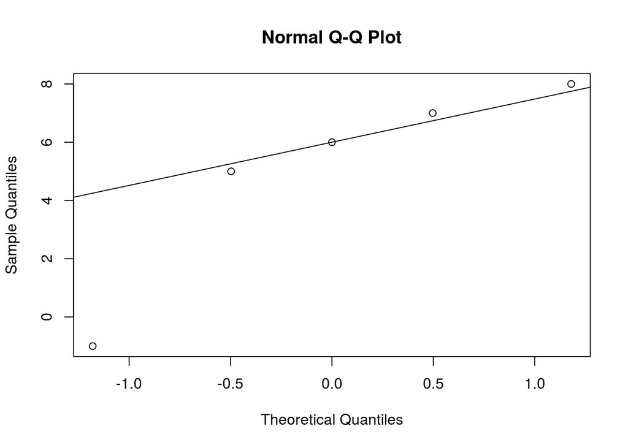

```r
  qqnorm(SUNDIG$difference)
  qqline(SUNDIG$difference)
```

Vemos que la mayoría de puntos que representan los cuantiles de la muestra se ajustan a la línea que representa los cuantiles de una normal teórica. En este caso puede ser más dudoso que en otros ejemplos asumir la normalidad. En el siguiente tema veremos otras herramientas que nos permitirán tomar la decisión sobre la asunción de normalidad.

Condiciones para el intervalo de confianza:

- 2 poblaciones con muestras relacionadas (ver justificación dada antes)
- Asumimos que la diferencia D=X-Y sigue una distribución normal (ver justificación dada antes)

```r
  t.test(SUNDIG$sun, SUNDIG$digital, paired=TRUE,conf.level=0.95)$conf
```

```
## [1] 0.6100548 9.3899452
## attr(,"conf.level")
## [1] 0.95
```

```r
  ##or

  t.test(SUNDIG$difference,conf.level=0.95)$conf
```

```
## [1] 0.6100548 9.3899452
## attr(,"conf.level")
## [1] 0.95
```

```r
ci <-   t.test(SUNDIG$sun, SUNDIG$digital, paired=TRUE,conf.level=0.95)$conf
LL <- round(ci[1],4)
UL <- round(ci[2],4)
```

Por tanto: CI$_{95\%}(\mu_X - \mu_Y)$= [0.6101, 9.3899] seg.